# Author: Jinad Patel

### Observations:

- 'Age': Age seems to have highest amount of skewness and also found good amount of outliers. Good candidate for Data processing.
- 'NumOfProducts': Seens to be having large cistomers with values 1 or 2. Minor outliers are there. It is noted as 2nd highest with the skewness.
- 'Tenure': Looks fairly distributed. No data processing needed.
- 'EstimatedSalary': Looks fairly disrtibuted. No data processing needed at this point.
- 'CreditScore': Negative small skewness found. Very few outliers on left side of box plot. Distribution is fairly normal.
- 'Balance': Little skewness found in the data. No outliers are present. Two peaks found for the distribution, this shows good amount of observations with 0 balance. All the observations with non zero balance are fairly distributed.

Note: All the observations from the graph supports out five point summary observations.

```python
# Find non unique values for the data set
df.nunique()
```

```
RowNumber          10000
CustomerId         10000
Surname             2932
CreditScore          460
Geography              3
Gender                 2
Age                   70
Tenure                11
Balance             6382
NumOfProducts          4
HasCrCard              2
IsActiveMember         2
EstimatedSalary     9999
Exited                 2
dtype: int64
```

```python
# As noted, Gender and Geography are good candidated to replace with numbers as we will be applying one hot encoding.
replace_struct = {
    'Geography': {'France' : 1,'Spain' : 2,'Germany' : 3},
    'Gender': {'Female' : 1, 'Male' : 2}
}

df_mod = df.replace(replace_struct)
df_mod
```

|  | RowNumber | CustomerId | Surname | CreditScore | Geography | Gender | Age | Tenure | Balance | NumOfProducts | HasCrCard | IsActiveMember | EstimatedSalary | Exited |
| --- | --- | --- | --- | --- | --- | --- | --- | --- | --- | --- | --- | --- | --- | --- |
| 0 | 1 | 15634602 | Hargrave | 619 | 1 | 1 | 42 | 2 | 0.00 | 1 | 1 | 1 | 101,348.88 | 1 |
| 1 | 2 | 15647311 | Hill | 608 | 2 | 1 | 41 | 1 | 83,807.86 | 1 | 0 | 1 | 112,542.58 | 0 |
| 2 | 3 | 15619304 | Onio | 502 | 1 | 1 | 42 | 8 | 159,660.80 | 3 | 1 | 0 | 113,931.57 | 1 |
| 3 | 4 | 15701354 | Boni | 699 | 1 | 1 | 39 | 1 | 0.00 | 2 | 0 | 0 | 93,826.63 | 0 |
| 4 | 5 | 15737888 | Mitchell | 850 | 2 | 1 | 43 | 2 | 125,510.82 | 1 | 1 | 1 | 79,084.10 | 0 |
| ... | ... | ... | ... | ... | ... | ... | ... | ... | ... | ... | ... | ... | ... | ... |
| 9995 | 9996 | 15606229 | Obijiaku | 771 | 1 | 2 | 39 | 5 | 0.00 | 2 | 1 | 0 | 96,270.64 | 0 |
| 9996 | 9997 | 15569892 | Johnstone | 516 | 1 | 2 | 35 | 10 | 57,369.61 | 1 | 1 | 1 | 101,699.77 | 0 |
| 9997 | 9998 | 15584532 | Liu | 709 | 1 | 1 | 36 | 7 | 0.00 | 1 | 0 | 1 | 42,085.58 | 1 |
| 9998 | 9999 | 15682355 | Sabbatini | 772 | 3 | 2 | 42 | 3 | 75,075.31 | 2 | 1 | 0 | 92,888.52 | 1 |
| 9999 | 10000 | 15628319 | Walker | 792 | 1 | 1 | 28 | 4 | 130,142.79 | 1 | 1 | 0 | 38,190.78 | 0 |

10000 rows × 14 columns

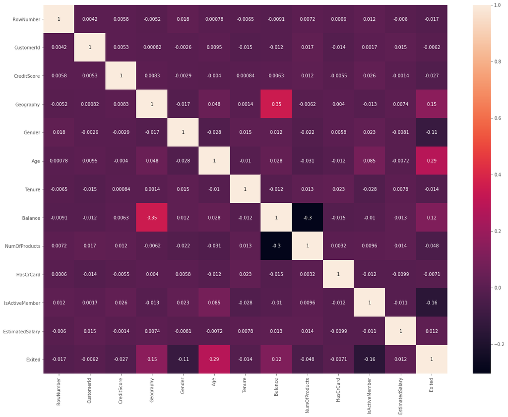

```python
# Univariate Analysis

# Heat map

sns.heatmap(df_mod.corr(), annot=True)
```

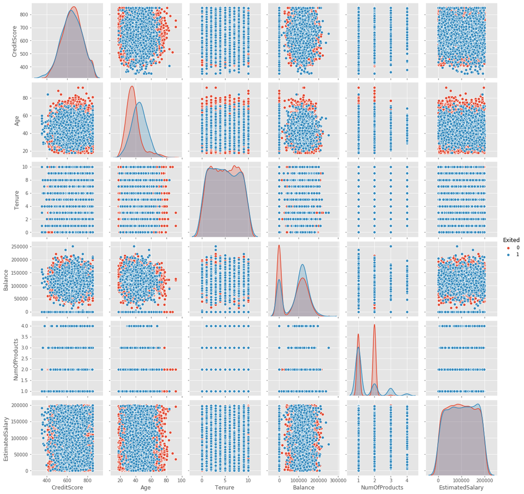

```python
# Pair plot
sns.pairplot(df_mod[numerical_cols + ['Exited']], diag_kind='kde', hue='Exited')
```